# 45_LogisticRegressionProject - Copy (2)

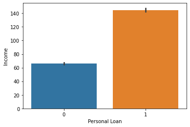

```python
#Comparison of non categorical independent variables with Personal Loan
#More Income more chances of getting loan
sns.barplot(x="Personal Loan", y="Income", data=data)
```

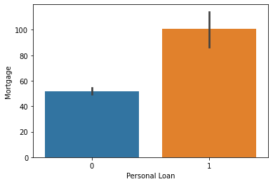

```python
#Comparison of non categorical independent variables with Personal Loan
#More Mortgage more chances of getting loan - Not considered where Mortgage is 0.
sns.barplot(x="Personal Loan", y="Mortgage", data=data)
```

```python
data.corr()
```

|  | ID | Age | Experience | Income | ZIP Code | Family | CCAvg | Education | Mortgage | Personal Loan | Securities Account | CD Account | Online | CreditCard |
| --- | --- | --- | --- | --- | --- | --- | --- | --- | --- | --- | --- | --- | --- | --- |
| ID | 1.0000 | -0.0085 | -0.0083 | -0.0177 | 0.0134 | -0.0168 | -0.0247 | 0.0215 | -0.0139 | -0.0248 | -0.0170 | -0.0069 | -0.0025 | 0.0170 |
| Age | -0.0085 | 1.0000 | 0.9942 | -0.0553 | -0.0292 | -0.0464 | -0.0520 | 0.0413 | -0.0125 | -0.0077 | -0.0004 | 0.0080 | 0.0137 | 0.0077 |
| Experience | -0.0083 | 0.9942 | 1.0000 | -0.0466 | -0.0286 | -0.0526 | -0.0501 | 0.0132 | -0.0106 | -0.0074 | -0.0012 | 0.0104 | 0.0139 | 0.0090 |
| Income | -0.0177 | -0.0553 | -0.0466 | 1.0000 | -0.0164 | -0.1575 | 0.6460 | -0.1875 | 0.2068 | 0.5025 | -0.0026 | 0.1697 | 0.0142 | -0.0024 |
| ZIP Code | 0.0134 | -0.0292 | -0.0286 | -0.0164 | 1.0000 | 0.0118 | -0.0041 | -0.0174 | 0.0074 | 0.0001 | 0.0047 | 0.0200 | 0.0170 | 0.0077 |
| Family | -0.0168 | -0.0464 | -0.0526 | -0.1575 | 0.0118 | 1.0000 | -0.1093 | 0.0649 | -0.0204 | 0.0614 | 0.0200 | 0.0141 | 0.0104 | 0.0116 |
| CCAvg | -0.0247 | -0.0520 | -0.0501 | 0.6460 | -0.0041 | -0.1093 | 1.0000 | -0.1361 | 0.1099 | 0.3669 | 0.0151 | 0.1365 | -0.0036 | -0.0067 |
| Education | 0.0215 | 0.0413 | 0.0132 | -0.1875 | -0.0174 | 0.0649 | -0.1361 | 1.0000 | -0.0333 | 0.1367 | -0.0108 | 0.0139 | -0.0150 | -0.0110 |
| Mortgage | -0.0139 | -0.0125 | -0.0106 | 0.2068 | 0.0074 | -0.0204 | 0.1099 | -0.0333 | 1.0000 | 0.1421 | -0.0054 | 0.0893 | -0.0060 | -0.0072 |
| Personal Loan | -0.0248 | -0.0077 | -0.0074 | 0.5025 | 0.0001 | 0.0614 | 0.3669 | 0.1367 | 0.1421 | 1.0000 | 0.0220 | 0.3164 | 0.0063 | 0.0028 |
| Securities Account | -0.0170 | -0.0004 | -0.0012 | -0.0026 | 0.0047 | 0.0200 | 0.0151 | -0.0108 | -0.0054 | 0.0220 | 1.0000 | 0.3170 | 0.0126 | -0.0150 |
| CD Account | -0.0069 | 0.0080 | 0.0104 | 0.1697 | 0.0200 | 0.0141 | 0.1365 | 0.0139 | 0.0893 | 0.3164 | 0.3170 | 1.0000 | 0.1759 | 0.2786 |
| Online | -0.0025 | 0.0137 | 0.0139 | 0.0142 | 0.0170 | 0.0104 | -0.0036 | -0.0150 | -0.0060 | 0.0063 | 0.0126 | 0.1759 | 1.0000 | 0.0042 |
| CreditCard | 0.0170 | 0.0077 | 0.0090 | -0.0024 | 0.0077 | 0.0116 | -0.0067 | -0.0110 | -0.0072 | 0.0028 | -0.0150 | 0.2786 | 0.0042 | 1.0000 |

```python
# However we want to see correlation in graphical representation so below is function for that
def plot_corr(df, size=12):
    corr = df.corr()
    fig, ax = plt.subplots(figsize=(size, size))
    ax.matshow(corr)
    plt.xticks(range(len(corr.columns)), corr.columns)
    plt.yticks(range(len(corr.columns)), corr.columns)
    plt.xticks(rotation = 90)
    for (i, j), z in np.ndenumerate(corr):
        ax.text(j, i, '{:0.4f}'.format(z), ha='center', va='center')
```

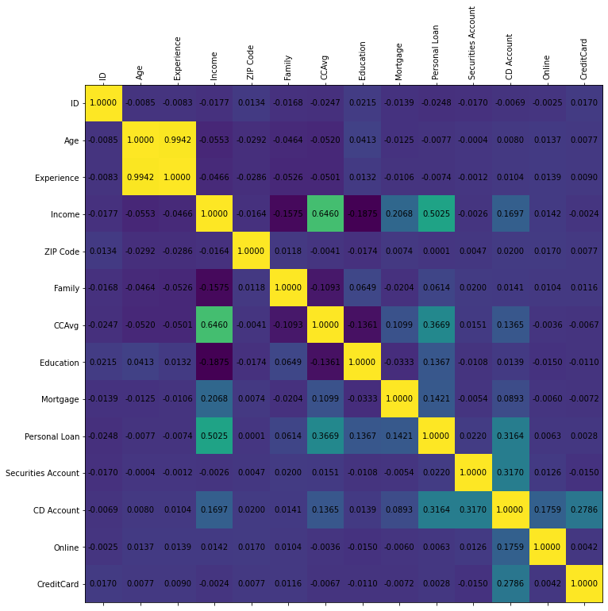

```python
plot_corr(data)
```

**Insights:**

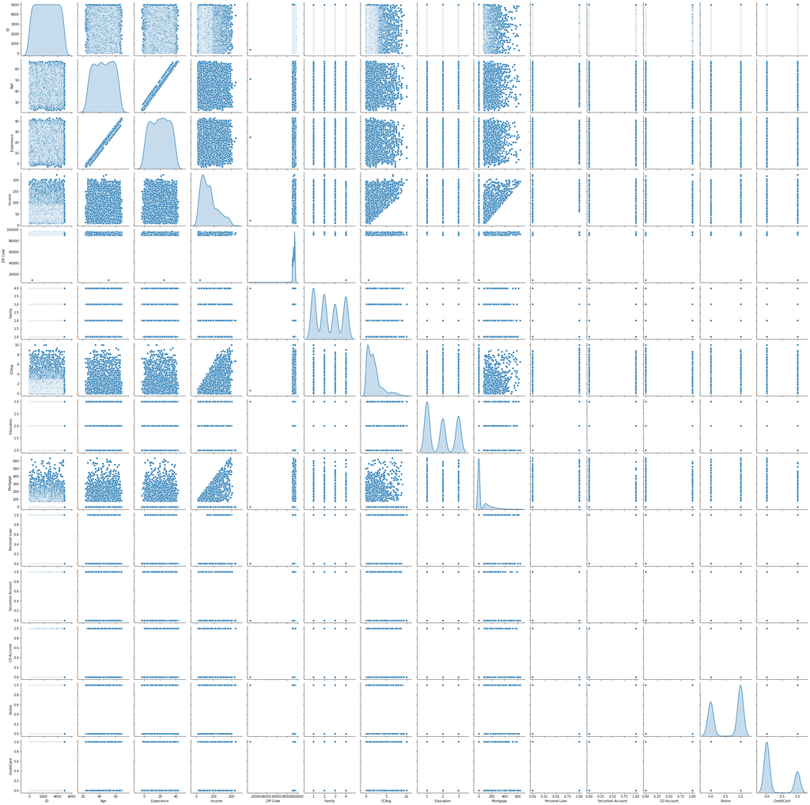

```python
sns.pairplot(data,diag_kind='kde')
```

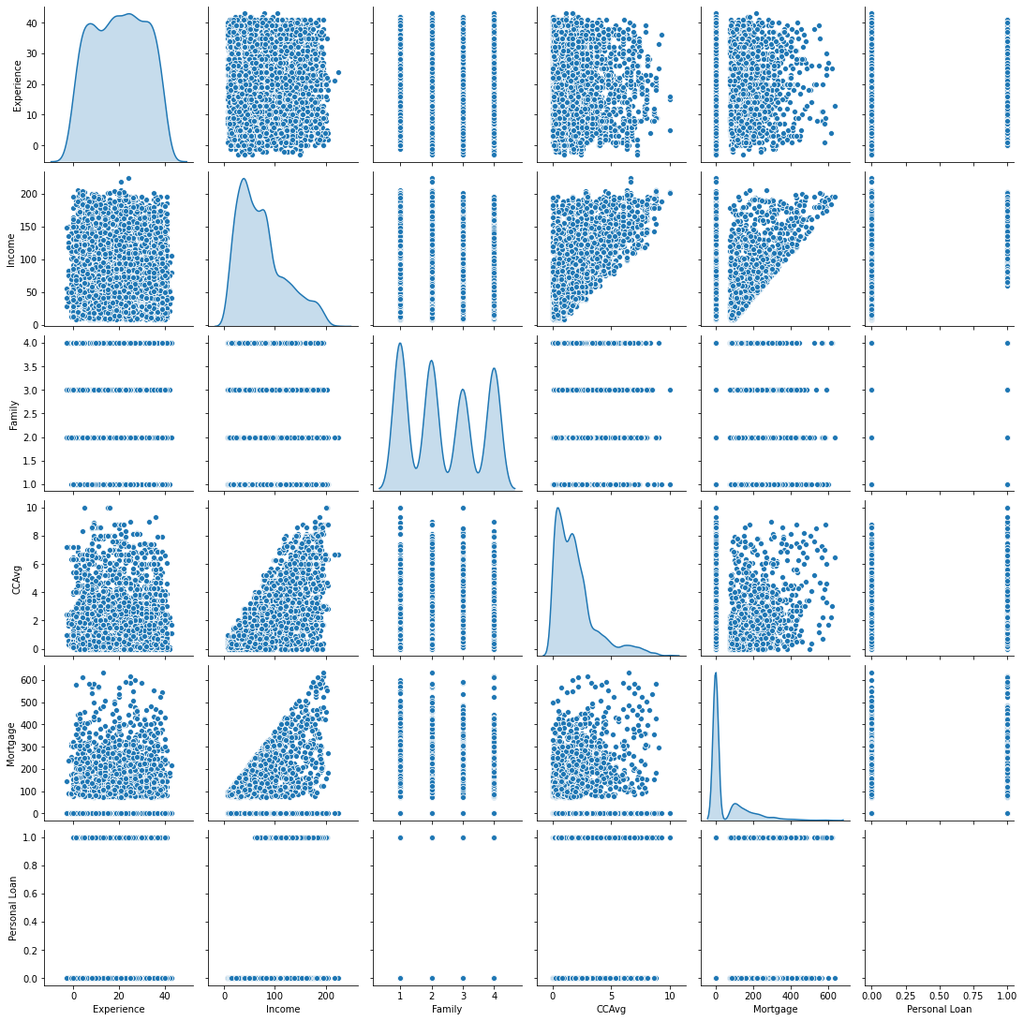

```python
#Droping binary categorical variable
sns.pairplot(data[['Experience','Income','Family','CCAvg','Mortgage','Personal Loan']],diag_kind='kde')
```

Get Data Model ready:- Review and fix Experience column values - Incorrect Imputations

```python
#Check the -ve values of Experience in in the similar range based on the Min and Max (-3 and 43)
# If it's in range then convert them to +ve assuming they were typo mistake while collecting the data
# Else replace with Mean or Mode
print('*******************Dataset Info where Experience is -ve************************')
print(data[data['Experience'] < 0 ])
print('*******************Check -ve experience is in range -3 and 43 as per previous Describe ************************')
print('*******************-ve Experience Min()************************')
print(data[data['Experience'] < 0 ]['Experience'].min())
print('*******************-ve Experience Max()************************')
print(data[data['Experience'] < 0 ]['Experience'].max())
```

```
*******************Dataset Info where Experience is -ve************************
        ID  Age  Experience  Income  ZIP Code  Family  CCAvg  Education  \
89      90   25          -1     113     94303       4 2.3000          3
226    227   24          -1      39     94085       2 1.7000          2
315    316   24          -2      51     90630       3 0.3000          3
451    452   28          -2      48     94132       2 1.7500          3
524    525   24          -1      75     93014       4 0.2000          1
536    537   25          -1      43     92173       3 2.4000          2
540    541   25          -1     109     94010       4 2.3000          3
576    577   25          -1      48     92870       3 0.3000          3
583    584   24          -1      38     95045       2 1.7000          2
597    598   24          -2     125     92835       2 7.2000          1
649    650   25          -1      82     92677       4 2.1000          3
670    671   23          -1      61     92374       4 2.6000          1
686    687   24          -1      38     92612       4 0.6000          2
```

[output cut: 152 more lines]

Based on above result, Experince is in Range -3 to 43. We will convert -ve to +ve Experience.

```python
print('*******************Data set after converting the Experience to +ve************************')
data['Experience'] = data['Experience'].abs()
print('*******************5 point summary of new Experience Column************************')
data['Experience'].describe()
```

```
*******************Data set after converting the Experience to +ve************************
*******************5 point summary of new Experience Column************************
```

```
count   5,000.0000
mean       20.1346
std        11.4152
min         0.0000
25%        10.0000
50%        20.0000
75%        30.0000
max        43.0000
Name: Experience, dtype: float64
```

```python
data.describe()
```

|  | ID | Age | Experience | Income | ZIP Code | Family | CCAvg | Education | Mortgage | Personal Loan | Securities Account | CD Account | Online | CreditCard |
| --- | --- | --- | --- | --- | --- | --- | --- | --- | --- | --- | --- | --- | --- | --- |
| count | 5,000.0000 | 5,000.0000 | 5,000.0000 | 5,000.0000 | 5,000.0000 | 5,000.0000 | 5,000.0000 | 5,000.0000 | 5,000.0000 | 5,000.0000 | 5,000.0000 | 5,000.0000 | 5,000.0000 | 5,000.0000 |
| mean | 2,500.5000 | 45.3384 | 20.1346 | 73.7742 | 93,152.5030 | 2.3964 | 1.9379 | 1.8810 | 56.4988 | 0.0960 | 0.1044 | 0.0604 | 0.5968 | 0.2940 |
| std | 1,443.5200 | 11.4632 | 11.4152 | 46.0337 | 2,121.8522 | 1.1477 | 1.7477 | 0.8399 | 101.7138 | 0.2946 | 0.3058 | 0.2383 | 0.4906 | 0.4556 |
| min | 1.0000 | 23.0000 | 0.0000 | 8.0000 | 9,307.0000 | 1.0000 | 0.0000 | 1.0000 | 0.0000 | 0.0000 | 0.0000 | 0.0000 | 0.0000 | 0.0000 |
| 25% | 1,250.7500 | 35.0000 | 10.0000 | 39.0000 | 91,911.0000 | 1.0000 | 0.7000 | 1.0000 | 0.0000 | 0.0000 | 0.0000 | 0.0000 | 0.0000 | 0.0000 |
| 50% | 2,500.5000 | 45.0000 | 20.0000 | 64.0000 | 93,437.0000 | 2.0000 | 1.5000 | 2.0000 | 0.0000 | 0.0000 | 0.0000 | 0.0000 | 1.0000 | 0.0000 |
| 75% | 3,750.2500 | 55.0000 | 30.0000 | 98.0000 | 94,608.0000 | 3.0000 | 2.5000 | 3.0000 | 101.0000 | 0.0000 | 0.0000 | 0.0000 | 1.0000 | 1.0000 |
| max | 5,000.0000 | 67.0000 | 43.0000 | 224.0000 | 96,651.0000 | 4.0000 | 10.0000 | 3.0000 | 635.0000 | 1.0000 | 1.0000 | 1.0000 | 1.0000 | 1.0000 |

Get Data Model ready:- Remove Id and Zipcode columns

```python
data.drop(columns ='ID',inplace=True)
data.drop(columns ='ZIP Code',inplace=True)
data
```

|  | Age | Experience | Income | Family | CCAvg | Education | Mortgage | Personal Loan | Securities Account | CD Account | Online | CreditCard |
| --- | --- | --- | --- | --- | --- | --- | --- | --- | --- | --- | --- | --- |
| 0 | 25 | 1 | 49 | 4 | 1.6000 | 1 | 0 | 0 | 1 | 0 | 0 | 0 |
| 1 | 45 | 19 | 34 | 3 | 1.5000 | 1 | 0 | 0 | 1 | 0 | 0 | 0 |
| 2 | 39 | 15 | 11 | 1 | 1.0000 | 1 | 0 | 0 | 0 | 0 | 0 | 0 |
| 3 | 35 | 9 | 100 | 1 | 2.7000 | 2 | 0 | 0 | 0 | 0 | 0 | 0 |
| 4 | 35 | 8 | 45 | 4 | 1.0000 | 2 | 0 | 0 | 0 | 0 | 0 | 1 |
| ... | ... | ... | ... | ... | ... | ... | ... | ... | ... | ... | ... | ... |
| 4995 | 29 | 3 | 40 | 1 | 1.9000 | 3 | 0 | 0 | 0 | 0 | 1 | 0 |
| 4996 | 30 | 4 | 15 | 4 | 0.4000 | 1 | 85 | 0 | 0 | 0 | 1 | 0 |
| 4997 | 63 | 39 | 24 | 2 | 0.3000 | 3 | 0 | 0 | 0 | 0 | 0 | 0 |
| 4998 | 65 | 40 | 49 | 3 | 0.5000 | 2 | 0 | 0 | 0 | 0 | 1 | 0 |
| 4999 | 28 | 4 | 83 | 3 | 0.8000 | 1 | 0 | 0 | 0 | 0 | 1 | 1 |

5000 rows × 12 columns

### 3. Split the data into training and test set in the ratio of 70:30 respectively

```python
#separating dependent and independent variables
X = data.drop("Personal Loan",axis=1)
Y = data['Personal Loan']
#print(X)
#print(Y)
```

```python
# Spilting the data into train and test

from sklearn.model_selection import train_test_split

X_train, X_test, y_train, y_test = train_test_split( X, Y, test_size = 0.3, random_state = 1)
```

```python
#Lets check split of data
print("{0:0.2f}% data is in training set".format((len(X_train)/len(data.index)) * 100))
print("{0:0.2f}% data is in test set".format((len(X_test)/len(data.index)) * 100))
```

```
70.00% data is in training set
30.00% data is in test set
```

```python
#Now lets check Personal Loan True/False ratio in split data
print("Original Personal Loan True Values    : {0} ({1:0.2f}%)".format(len(data.loc[data['Personal Loan'] == 1]), (len(data.loc[data['Personal Loan'] == 1])/len(data.index)) * 100))
print("Original Personal Loan False Values   : {0} ({1:0.2f}%)".format(len(data.loc[data['Personal Loan'] == 0]), (len(data.loc[data['Personal Loan'] == 0])/len(data.index)) * 100))
print("")
print("Training Personal Loan True Values    : {0} ({1:0.2f}%)".format(len(y_train[y_train[:] == 1]), (len(y_train[y_train[:] == 1])/len(y_train)) * 100))
print("Training Personal Loan False Values   : {0} ({1:0.2f}%)".format(len(y_train[y_train[:] == 0]), (len(y_train[y_train[:] == 0])/len(y_train)) * 100))
print("")
print("Test Personal Loan True Values        : {0} ({1:0.2f}%)".format(len(y_test[y_test[:] == 1]), (len(y_test[y_test[:] == 1])/len(y_test)) * 100))
print("Test Personal Loan False Values       : {0} ({1:0.2f}%)".format(len(y_test[y_test[:] == 0]), (len(y_test[y_test[:] == 0])/len(y_test)) * 100))
print("")
```

```
Original Personal Loan True Values    : 480 (9.60%)
Original Personal Loan False Values   : 4520 (90.40%)

Training Personal Loan True Values    : 331 (9.46%)
Training Personal Loan False Values   : 3169 (90.54%)

Test Personal Loan True Values        : 149 (9.93%)
Test Personal Loan False Values       : 1351 (90.07%)
```

### 4. Use the Logistic Regression model to predict whether the customer will take a personal loan or not. Print all the metrics related to evaluating the model performance (accuracy, recall, precision, f1score, and roc_auc_score). Draw a heatmap to display confusion matrix

```python
from sklearn.linear_model import LogisticRegression

lr = LogisticRegression(random_state=7)
lr.fit(X_train,y_train)
```

```
LogisticRegression(random_state=7)
```

```python
y_predicted =  lr.predict(X_test)
y_predicted
y_pred_proba = lr.predict_proba(X_test)[::,1]
```

```python
z = pd.DataFrame()                                               # creating a new dataframe
z['Actual'] = y_test.values                                      # Storing actual output of target variable

z['Probaility that output is 0'] = lr.predict_proba(X_test)[:,0]
# Probabilities predicted by Logistic regression model
z['Probaility that output is 1'] = lr.predict_proba(X_test)[:,1]

z['Predicted'] = lr.predict(X_test)                               # Predicting target variable using sklearn Logistic regression

z.head()

# In sklearn default threshold is 0.5
# therfore for all the values whose probability for 1 is greater than 0.5 will be predicted as 1
```

|  | Actual | Probaility that output is 0 | Probaility that output is 1 | Predicted |
| --- | --- | --- | --- | --- |
| 0 | 0 | 0.9776 | 0.0224 | 0 |
| 1 | 0 | 0.9994 | 0.0006 | 0 |
| 2 | 0 | 0.9990 | 0.0010 | 0 |
| 3 | 0 | 0.9959 | 0.0041 | 0 |
| 4 | 0 | 0.9676 | 0.0324 | 0 |

```python
from sklearn.metrics import accuracy_score
print( 'Total Accuracy : ',np.round( accuracy_score( y_test, lr.predict(X_test) ), 2 ) )
```

```
Total Accuracy :  0.94
```

```python
from sklearn.metrics import classification_report
print(classification_report(y_test, y_predicted))
```

```
              precision    recall  f1-score   support

           0       0.95      0.99      0.97      1351
           1       0.82      0.56      0.66       149

    accuracy                           0.94      1500
   macro avg       0.89      0.77      0.82      1500
weighted avg       0.94      0.94      0.94      1500
```

```python
from sklearn import metrics
auc = metrics.roc_auc_score(y_test, y_pred_proba)
print('roc_auc_score: ',auc)
```

```
roc_auc_score:  0.9513360722109896
```

```python
from sklearn.metrics import confusion_matrix
```

```python
def draw_cm( actual, predicted ):
    cm = confusion_matrix( actual, predicted, [1,0] )
    sns.heatmap(cm, annot=True,  fmt='.2f', xticklabels = ["Loan", "NoLoan"] , yticklabels = ["Loan", "No Loan"] )
    plt.ylabel('True label')
    plt.xlabel('Predicted label')
    plt.show()
```

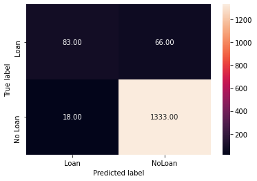

```python
draw_cm( z['Actual'], z['Predicted'] )
# draw_cm( y_test, lr.predict(X_test) )
#draw_cm( y_test, y_predicted )
```

### 5. Find out coefficients of all the attributes and show the output in a data frame with column names? For test data show all the rows where the predicted class is not equal to the observed class

```python
X_test.columns
```

```
Index(['Age', 'Experience', 'Income', 'Family', 'CCAvg', 'Education',
       'Mortgage', 'Securities Account', 'CD Account', 'Online', 'CreditCard'],
      dtype='object')
```

```python
coef_df = pd.DataFrame(lr.coef_,columns=X.columns)
#coef_df['intercept'] = lr.intercept_
print('************ Coefficients of all the attributes with Column names ***************')
print(coef_df)
```

```
************ Coefficients of all the attributes with Column names ***************
      Age  Experience  Income  Family  CCAvg  Education  Mortgage  \
0 -0.4731      0.4759  0.0475  0.6494 0.2044     1.6160    0.0009

   Securities Account  CD Account  Online  CreditCard
0             -0.4524      2.8361 -0.6375     -1.0429
```

```python
import statsmodels.api as sm

logit = sm.Logit( y_train, sm.add_constant( X_train ) )

lg = logit.fit()

lg.summary2()
```

```
Optimization terminated successfully.
         Current function value: 0.124450
         Iterations 9
```

| Model: | Logit | Pseudo R-squared: | 0.602 |
| --- | --- | --- | --- |
| Dependent Variable: | Personal Loan | AIC: | 895.1508 |
| Date: | 2020-10-07 14:57 | BIC: | 969.0770 |
| No. Observations: | 3500 | Log-Likelihood: | -435.58 |
| Df Model: | 11 | LL-Null: | -1095.5 |
| Df Residuals: | 3488 | LLR p-value: | 2.4389e-276 |
| Converged: | 1.0000 | Scale: | 1.0000 |
| No. Iterations: | 9.0000 |  |  |

|  | Coef. | Std.Err. | z | P>\|z\| | [0.025 | 0.975] |
| --- | --- | --- | --- | --- | --- | --- |
| const | -13.2839 | 1.9149 | -6.9370 | 0.0000 | -17.0371 | -9.5307 |
| Age | -0.0145 | 0.0704 | -0.2053 | 0.8373 | -0.1525 | 0.1236 |
| Experience | 0.0197 | 0.0705 | 0.2788 | 0.7804 | -0.1186 | 0.1579 |
| Income | 0.0537 | 0.0032 | 16.8236 | 0.0000 | 0.0474 | 0.0599 |
| Family | 0.7299 | 0.0928 | 7.8657 | 0.0000 | 0.5480 | 0.9118 |
| CCAvg | 0.1723 | 0.0486 | 3.5456 | 0.0004 | 0.0771 | 0.2676 |
| Education | 1.7274 | 0.1407 | 12.2754 | 0.0000 | 1.4516 | 2.0032 |
| Mortgage | 0.0008 | 0.0007 | 1.1532 | 0.2488 | -0.0005 | 0.0021 |
| Securities Account | -1.1977 | 0.3707 | -3.2307 | 0.0012 | -1.9243 | -0.4711 |
| CD Account | 3.8812 | 0.3993 | 9.7193 | 0.0000 | 3.0986 | 4.6639 |
| Online | -0.6359 | 0.1909 | -3.3315 | 0.0009 | -1.0101 | -0.2618 |
| CreditCard | -1.1811 | 0.2505 | -4.7149 | 0.0000 | -1.6720 | -0.6901 |

```python
z = X_test.copy()
z['Observed Loan Status'] = y_test
z['Predicted Loan Status'] = y_predicted
z.head()
```

|  | Age | Experience | Income | Family | CCAvg | Education | Mortgage | Securities Account | CD Account | Online | CreditCard | Observed Loan Status | Predicted Loan Status |
| --- | --- | --- | --- | --- | --- | --- | --- | --- | --- | --- | --- | --- | --- |
| 2764 | 31 | 5 | 84 | 1 | 2.9000 | 3 | 105 | 0 | 0 | 0 | 1 | 0 | 0 |
| 4767 | 35 | 9 | 45 | 3 | 0.9000 | 1 | 101 | 1 | 0 | 0 | 0 | 0 | 0 |
| 3814 | 34 | 9 | 35 | 3 | 1.3000 | 1 | 0 | 0 | 0 | 0 | 0 | 0 | 0 |
| 3499 | 49 | 23 | 114 | 1 | 0.3000 | 1 | 286 | 0 | 0 | 1 | 0 | 0 | 0 |
| 2735 | 36 | 12 | 70 | 3 | 2.6000 | 2 | 165 | 0 | 0 | 1 | 0 | 0 | 0 |

```python
#For test data show all the rows where the predicted class is not equal to the observed clas
z[z['Observed Loan Status'] != z['Predicted Loan Status']]
```

|  | Age | Experience | Income | Family | CCAvg | Education | Mortgage | Securities Account | CD Account | Online | CreditCard | Observed Loan Status | Predicted Loan Status |
| --- | --- | --- | --- | --- | --- | --- | --- | --- | --- | --- | --- | --- | --- |
| 1513 | 45 | 21 | 183 | 2 | 1.4000 | 1 | 354 | 0 | 0 | 0 | 0 | 0 | 1 |
| 3347 | 65 | 41 | 78 | 3 | 2.0000 | 3 | 0 | 0 | 1 | 1 | 1 | 0 | 1 |
| 4377 | 33 | 8 | 145 | 1 | 2.7000 | 3 | 0 | 0 | 0 | 1 | 0 | 1 | 0 |
| 3271 | 52 | 27 | 93 | 4 | 4.1000 | 2 | 0 | 0 | 0 | 0 | 1 | 1 | 0 |
| 349 | 26 | 2 | 60 | 2 | 3.0000 | 1 | 132 | 0 | 0 | 0 | 0 | 1 | 0 |
| ... | ... | ... | ... | ... | ... | ... | ... | ... | ... | ... | ... | ... | ... |
| 4285 | 23 | 3 | 149 | 2 | 7.2000 | 1 | 0 | 0 | 0 | 1 | 0 | 0 | 1 |
| 813 | 50 | 25 | 130 | 1 | 1.1000 | 2 | 0 | 0 | 0 | 1 | 0 | 1 | 0 |
| 3766 | 59 | 35 | 108 | 4 | 3.8000 | 2 | 304 | 0 | 0 | 1 | 0 | 1 | 0 |
| 421 | 28 | 3 | 115 | 4 | 3.1000 | 2 | 0 | 0 | 0 | 0 | 0 | 1 | 0 |
| 3651 | 49 | 23 | 140 | 1 | 1.9000 | 3 | 0 | 0 | 0 | 0 | 1 | 1 | 0 |

84 rows × 13 columns

### 6. Give conclusion related to the Business understanding of your model?

The model created performed well on the test data with accuracy of 94% and a weighted average Recall of 0.94. Which is a significant jump from their previous success ratio.

As per the EDA analysis, there is a high correlation with Income (0.5025), CC Avg (0.3669) and CD Account (0.3164). Targetting those customer will increase the chance of sellign Personal Loan account and at the same time this will bring down the Marketing campaing cost as we are approaching specific class of customers.